Vignette - Computational proteomics of a THP-1 human leukaemia cell line Lisa M Breckels 15/04/2021

# Abstract

This vignette contains the pipeline used for the computational analysis reported in the paper “Spatiotemporal proteomic profiling of the pro-inflammatory response to lipopolysaccharide in the THP-1 human leukemia cell line” by Mulvey, Breckels et al [1].

# The data

All raw mass spectrometry proteomics data from this study have been deposited to the [ProteomeXchange](http://proteomecentral.proteomexchange.org/cgi/GetDataset) Consortium via the PRIDE partner repository [2], with the dataset identifier PXD023509. The peptide and protein level datasets are also freely and openly available as part of the [Bioconductor pRolocdata package](https://bioconductor.org/packages/release/data/experiment/html/pRolocdata.html) (≥v1.27.3) [3] and are also available in the supplementary information as disseminated with the accompanying manuscript [1].

All analysis in the manuscript is done in the R programming language, unless otherwise stated, using the suite of mass spectrometry spatial proteomics packages [`MSnbase`](https://www.bioconductor.org/packages/release/bioc/html/MSnbase.html), [`pRoloc`](https://www.bioconductor.org/packages/release/bioc/html/pRoloc.html), [`pRolocGUI`](https://www.bioconductor.org/packages/release/bioc/html/pRolocGUI.html) and [`pRolocdata`](https://bioconductor.org/packages/release/data/experiment/html/pRolocdata.html).

## Accessing the data in R

The `pRolocdata` package is a R [Bioconductor](http://bioconductor.org/) [experiment package](http://bioconductor.org/packages/release/BiocViews.html#___ExperimentData) that collects mass spectrometry-based spatial/organelle and protein-complex datasets from published experiments. Each data is stored in a container called a `MSnSet` instance (see the [`MSnbase`](http://www.bioconductor.org/packages/release/bioc/html/MSnbase.html) for details) which allows users to work seamlessly with the R [`pRoloc`](http://bioconductor.org/packages/release/data/experiment/html/pRolocdata.html) and [`pRolocGUI`](http://bioconductor.org/packages/devel/bioc/html/pRolocGUI.html) software for spatial proteomics data analysis and visualisation.

The first step is to install the `pRoloc` package from Bioconductor and the `devtools` package to access `pRolocdata` on Github

```r
if (!requireNamespace("BiocManager", quietly = TRUE))
    install.packages("BiocManager")
BiocManager::install("pRoloc")
BiocManager::install("devtools")

## we also use the knitr and VennDiagram, ggplot2 packages in this
## vignette so please  install if you do not have them
BiocManager::install(c("knitr", "VennDiagram", "ggplot2", "dplyr", "kableExtra", "coda"))
```

Note: We can install the `pRolocdata` package from Bioconductor using the same method e.g. `BiocManager::install("pRolocdata")` however we require version >=1.29.1 which is not yet available on Bioconductor until the next stable release ([Thursday 20th May](http://www.bioconductor.org/developers/release-schedule/)). In the meantime we can access it via Github using the R package `devtools` using the below commands.

```r
library("devtools")
install_github("https://github.com/lgatto/pRolocdata")
```

Now we can load the packages by calling `library` function in R

```r
library("pRoloc")
library("pRolocdata")
```

and subsequently we can now access all the datasets in `pRolocdata`. To list all available datasets we use the `data` function.

```r
data(package = "pRolocdata")
```

We see there are 27 datasets (including the PSM and protein level data) associated with the manuscript [1], 20 from the hyperLOPIT data anlysis and 7 from the LPS timecourse [1]. For more information on these datasets, we can type

```r
?thpLOPIT_lps_mulvey2021
?lpsTimecourse_mulvey2021
```

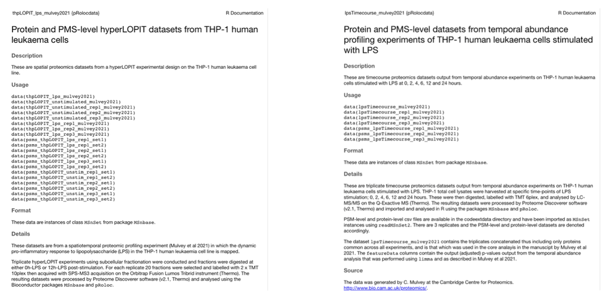

*Figure 1. Screenshot of the documentation files in R for the THP LOPIT and LPS timecourse datasets*

Each dataset can be loaded using the `data` function. For example, to load the final protein level LOPIT datasets for the unstimulated and 12 hour LPS stimulated datasets,

```r
data("thpLOPIT_unstimulated_mulvey2021")
thpLOPIT_unstimulated_mulvey2021

data("thpLOPIT_lps_mulvey2021")
thpLOPIT_lps_mulvey2021
```

In the next section we introduce the data, experimental design and brief overview of the experimental protocol before walking users through the downstream analysis.

# 1. Spatial proteomics

## The hyperLOPIT workflow

Using the hyperLOPIT proteomics platform [4, 5] we obtained spatial maps that capture the steady-state distribution of thousands of proteins in the THP-1 human leukaemia cell line. Experiments were conducted in triplicate and the samples were analysed and collected when cells were (1) unstimulated and then (2) at 12 hours following stimulation with LPS.

The hyperLOPIT method combines biochemical cell fractionation with multiplexed high-resolution mass-spectrometry [4, 5], the full protocol and experimental design can be found in [1]. Briefly, TMT labelling was conducted as described in [5] and 20 fractions including the cytosol-enriched fraction were labelled per gradient, by combining two TMT 10-plex experiments in an interleaved labelling design to capture as much subcellular diversity as possible. The experimental design for each dataset is stored in the `pData` slot of each dataset.

To access the full experimental design use the `pData` function

```r
## TMT experiment data for the unstimulated hyperLOPIT data
pData(thpLOPIT_unstimulated_mulvey2021)
```

```
##                               Tag    Treatment Replicate Set Fraction
## unstim_rep1_set1_126_cyto     126 Unstimulated         1   1     cyto
## unstim_rep2_set1_126_cyto     126 Unstimulated         2   1     cyto
## unstim_rep3_set1_126_cyto     126 Unstimulated         3   1     cyto
## unstim_rep1_set1_127N_F1.4   127N Unstimulated         1   1     F1.4
## unstim_rep2_set1_127N_F1.6   127N Unstimulated         2   1     F1.6
## unstim_rep3_set1_127N_F1.6   127N Unstimulated         3   1     F1.6
## unstim_rep1_set2_126_F5.6     126 Unstimulated         1   2     F5.6
## unstim_rep1_set1_127C_F7     127C Unstimulated         1   1       F7
## unstim_rep2_set2_127N_F7.8   127N Unstimulated         2   2     F7.8
## unstim_rep3_set2_126_F7.8     126 Unstimulated         3   2     F7.8
## unstim_rep1_set2_127N_F8     127N Unstimulated         1   2       F8
## unstim_rep1_set1_128N_F9     128N Unstimulated         1   1       F9
## unstim_rep3_set1_127C_F9     127C Unstimulated         3   1       F9
## unstim_rep2_set1_127C_F9.10  127C Unstimulated         2   1    F9.10
## unstim_rep1_set2_127C_F10    127C Unstimulated         1   2      F10
## unstim_rep3_set2_127N_F10    127N Unstimulated         3   2      F10
## unstim_rep1_set1_128C_F11    128C Unstimulated         1   1      F11
## unstim_rep3_set1_128N_F11    128N Unstimulated         3   1      F11
## unstim_rep2_set2_127C_F11.12 127C Unstimulated         2   2   F11.12
## unstim_rep1_set2_128N_F12    128N Unstimulated         1   2      F12
## unstim_rep2_set1_128N_F12    128N Unstimulated         2   1      F12
## unstim_rep3_set2_127C_F12    127C Unstimulated         3   2      F12
## unstim_rep1_set1_129N_F13    129N Unstimulated         1   1      F13
## unsti_rep2_set2_128N_F13     128N Unstimulated         2   2      F13
## unstim_rep3_set1_128C_F13    128C Unstimulated         3   1      F13
## unstim_rep1_set2_128C_F14    128C Unstimulated         1   2      F14
## unstim_rep2_set1_128C_F14    128C Unstimulated         2   1      F14
## unstim_rep3_set2_128N_F14    128N Unstimulated         3   2      F14
## unstim_rep1_set1_129C_F15    129C Unstimulated         1   1      F15
## unstim_rep2_set2_128C_F15    128C Unstimulated         2   2      F15
## unstim_rep3_set1_129N_F15    129N Unstimulated         3   1      F15
## unstim_rep1_set2_129N_F16    129N Unstimulated         1   2      F16
## unstim_rep2_set1_129N_F16    129N Unstimulated         2   1      F16
## unstim_rep3_set2_128C_F16    128C Unstimulated         3   2      F16
## unstim_rep1_set1_130N_F17    130N Unstimulated         1   1      F17
## unstim_rep2_set2_129N_F17    129N Unstimulated         2   2      F17
## unstim_rep3_set1_129C_F17    129C Unstimulated         3   1      F17
## unstim_rep1_set2_129C_F18    129C Unstimulated         1   2      F18
## unstim_rep2_set1_129C_F18    129C Unstimulated         2   1      F18
## unstim_rep3_set2_129N_F18    129N Unstimulated         3   2      F18
## unstim_rep1_set1_130C_F19    130C Unstimulated         1   1      F19
## unstim_rep2_set2_129C_F19    129C Unstimulated         2   2      F19
## unstim_rep3_set1_130N_F19    130N Unstimulated         3   1      F19
## unstim_rep1_set2_130N_F20    130N Unstimulated         1   2      F20
## unstim_rep2_set1_130N_F20    130N Unstimulated         2   1      F20
## unstim_rep3_set2_129C_F20    129C Unstimulated         3   2      F20
## unstim_rep1_set1_131_F21      131 Unstimulated         1   1      F21
## unstim_rep2_set2_130N_F21    130N Unstimulated         2   2      F21
## unstim_rep3_set1_130C_F21    130C Unstimulated         3   1      F21
## unstim_rep1_set2_130C_F22    130C Unstimulated         1   2      F22
## unstim_rep2_set1_130C_F22    130C Unstimulated         2   1      F22
## unstim_rep3_set2_130N_F22    130N Unstimulated         3   2      F22
## unstim_rep2_set2_130C_F23    130C Unstimulated         2   2      F23
## unstim_rep3_set1_131_F23      131 Unstimulated         3   1      F23
## unstim_rep1_set2_131_F24      131 Unstimulated         1   2      F24
## unstim_rep2_set1_131_F24      131 Unstimulated         2   1      F24
## unstim_rep3_set2_130C_F24    130C Unstimulated         3   2      F24
## unstim_rep2_set2_131_F25      131 Unstimulated         2   2      F25
## unstim_rep3_set2_131_F26      131 Unstimulated         3   2      F26
```

```r
## TMT labelling scheme for the LPS hyperLOPIT data
pData(thpLOPIT_lps_mulvey2021)
```

```
##                           Tag Treatment Replicate Set Fraction
## lps_rep1_set1_126_cyto    126       LPS         1   1     cyto
## lps_rep2_set1_126_cyto    126       LPS         2   1     cyto
## lps_rep3_set1_126_cyto    126       LPS         3   1     cyto
## lps_rep1_set1_127N_F1.4  127N       LPS         1   1     F1.4
## lps_rep2_set1_127N_F1.6  127N       LPS         2   1     F1.6
## lps_rep3_set1_127N_F1.6  127N       LPS         3   1     F1.6
## lps_rep1_set2_126_F5.7    126       LPS         1   2     F5.7
## lps_rep2_set2_126_F7.8    126       LPS         2   2     F7.8
## lps_rep3_set2_126_F7.8    126       LPS         3   2     F7.8
## lps_rep1_set1_127C_F8    127C       LPS         1   1       F8
## lps_rep1_set2_127N_F9    127N       LPS         1   2       F9
## lps_rep3_set1_127C_F9    127C       LPS         3   1       F9
## lps_rep2_set1_127C_F9.10 127C       LPS         2   1    F9.10
## lps_rep1_set1_128N_F10   128N       LPS         1   1      F10
## lps_rep3_set2_127N_F10   127N       LPS         3   2      F10
## lps_rep1_set2_127C_F11   127C       LPS         1   2      F11
## lps_rep2_set2_127N_F11   127N       LPS         2   2      F11
## lps_rep3_set1_128N_F11   128N       LPS         3   1      F11
## lps_rep1_set1_128C_F12   128C       LPS         1   1      F12
## lps_rep2_set1_128N_F12   128N       LPS         2   1      F12
## lps_rep3_set2_127C_F12   127C       LPS         3   2      F12
## lps_rep1_set2_128N_F13   128N       LPS         1   2      F13
## lps_rep2_set2_127C_F13   127C       LPS         2   2      F13
## lps_rep3_set1_128C_F13   128C       LPS         3   1      F13
## lps_rep1_set1_129N_F14   129N       LPS         1   1      F14
## lps_rep2_set1_128C_F14   128C       LPS         2   1      F14
## lps_rep3_set2_128N_F14   128N       LPS         3   2      F14
## lps_rep1_set2_128C_F15   128C       LPS         1   2      F15
## lps_rep2_set2_128N_F15   128N       LPS         2   2      F15
## lps_rep3_set1_129N_F15   129N       LPS         3   1      F15
## lps_rep1_set1_129C_F16   129C       LPS         1   1      F16
## lps_rep2_set1_129N_F16   129N       LPS         2   1      F16
## lps_rep3_set2_128C_F16   128C       LPS         3   2      F16
## lps_rep1_set2_129N_F17   129N       LPS         1   2      F17
## lps_rep2_set2_128C_F17   128C       LPS         2   2      F17
## lps_rep3_set1_129C_F17   129C       LPS         3   1      F17
## lps_rep1_set1_130N_F18   130N       LPS         1   1      F18
## lps_rep2_set1_129C_F18   129C       LPS         2   1      F18
## lps_rep3_set2_129N_F18   129N       LPS         3   2      F18
## lps_rep1_set2_129C_F19   129C       LPS         1   2      F19
## lps_rep2_set2_129N_F19   129N       LPS         2   2      F19
## lps_rep3_set1_130N_F19   130N       LPS         3   1      F19
## lps_rep1_set1_130C_F20   130C       LPS         1   1      F20
## lps_rep2_set1_130N_F20   130N       LPS         2   1      F20
## lps_rep3_set2_129C_F20   129C       LPS         3   2      F20
## lps_rep1_set2_130N_F21   130N       LPS         1   2      F21
## lps_rep2_set2_129C_F21   129C       LPS         2   2      F21
## lps_rep3_set1_130C_F21   130C       LPS         3   1      F21
## lps_rep1_set1_131_F22     131       LPS         1   1      F22
## lps_rep2_set1_130C_F22   130C       LPS         2   1      F22
## lps_rep3_set2_130N_F22   130N       LPS         3   2      F22
## lps_rep1_set2_130C_F23   130C       LPS         1   2      F23
## lps_rep2_set2_130N_F23   130N       LPS         2   2      F23
## lps_rep3_set1_131_F23     131       LPS         3   1      F23
## lps_rep2_set1_131_F24     131       LPS         2   1      F24
## lps_rep3_set2_130C_F24   130C       LPS         3   2      F24
## lps_rep1_set2_131_F25     131       LPS         1   2      F25
## lps_rep2_set2_130C_F25   130C       LPS         2   2      F25
## lps_rep3_set2_131_F26     131       LPS         3   2      F26
```

As described in [1] and [5] the data was processed with Proteome Discoverer v2.1 (Thermo Fisher Scientific) and Mascot server v2.3.02 (Matrix Science) using the SwissProt sequence database for Homo sapiens (www.uniprot.org in November 2016) and the cRAP database (common Repository for Adventitious Proteins, https://www.thegpm.org/crap). Standard filtering of the raw data was conducted as per [1] and [5] to remove contaminants and low abundant PSMs. A maximum of two missing values per TMT experiment was allowed and the data was directly exported from Proteome Discoverer at the PSM level for downstream analysis in R.

The experiments were done in triplicate for each condition and each replicate contains 2 x TMT 10-plex sets (which we denote as “set 1” and “set 2”). Thus, in total we conducted a total of 12 experiments, 6 per condition wherein we had 2 sets per replicate containing a total of 20 fractions/channels per replicate. One TMT channel was removed (TMT tag 126 in replicate 2, set 2 in the unstimulated) due to erroneous labelling of insoluble material during the sample preparation for this specific tag. The “Average Reporter S/N” value was recalculated for the nine remaining channels in the corresponding 10plex set and PSMs with a value less than 9.0 were discarded (please see Data Processing in the Supplementary Information of [1]).

## PSM level data processing

### Missing values assessment

The 12 PSM level datasets were imported into R and missing values were carefully assessed.

Load the PSM level unstimulated data,

```r
## Unstimulated data
data("psms_thpLOPIT_unstim_rep1_set1")
data("psms_thpLOPIT_unstim_rep1_set2")

data("psms_thpLOPIT_unstim_rep2_set1")
data("psms_thpLOPIT_unstim_rep2_set2")

data("psms_thpLOPIT_unstim_rep3_set1")
data("psms_thpLOPIT_unstim_rep3_set2")
```

Load the PSM level 12h-LPS stimulated data,

```r
## 12h post LPS-stimulated
data("psms_thpLOPIT_lps_rep1_set1")
data("psms_thpLOPIT_lps_rep1_set2")

data("psms_thpLOPIT_lps_rep2_set1")
data("psms_thpLOPIT_lps_rep2_set2")

data("psms_thpLOPIT_lps_rep3_set1")
data("psms_thpLOPIT_lps_rep3_set2")
```

For ease of coding we create a list of `MSnSets` for each condition

```r
psms <- MSnSetList(
  list(
    psms_thpLOPIT_unstim_rep1_set1,
    psms_thpLOPIT_unstim_rep1_set2,
    psms_thpLOPIT_unstim_rep2_set1,
    psms_thpLOPIT_unstim_rep2_set2,
    psms_thpLOPIT_unstim_rep3_set1,
    psms_thpLOPIT_unstim_rep3_set2,
    psms_thpLOPIT_lps_rep1_set1,
    psms_thpLOPIT_lps_rep1_set2,
    psms_thpLOPIT_lps_rep2_set1,
    psms_thpLOPIT_lps_rep2_set2,
    psms_thpLOPIT_lps_rep3_set1,
    psms_thpLOPIT_lps_rep3_set2
  )
)

## add list names for each dataset
.nams <- paste0("Rep", rep(1:3, each = 2), "_set", rep(1:2, 3))
names(psms) <- c(paste0(.nams, "_unstim"), paste0(.nams, "_lps"))
```

We can view the number of PSMs per experiment,

```r
sapply(psms, nrow)
```

```
## Rep1_set1_unstim Rep1_set2_unstim Rep2_set1_unstim Rep2_set2_unstim
##            44137            41860            39297            37919
## Rep3_set1_unstim Rep3_set2_unstim    Rep1_set1_lps    Rep1_set2_lps
##            48199            44802            40994            63844
##    Rep2_set1_lps    Rep2_set2_lps    Rep3_set1_lps    Rep3_set2_lps
##            43799            44055            46805            45600
```

If we examine the corresponding protein group of each PSM with a missing value, we find that there are other PSMs available for quantitation for the majority of proteins. There are still several hundred cases where we only have 1 PSM for a given protein group, so we would lose several hundred proteins per replicate if we were to just remove these PSMs. We assess the missing values across all experiments using the `naPlot` function to see if there is a trend in where missing values occur.

Generate `naPlots`,

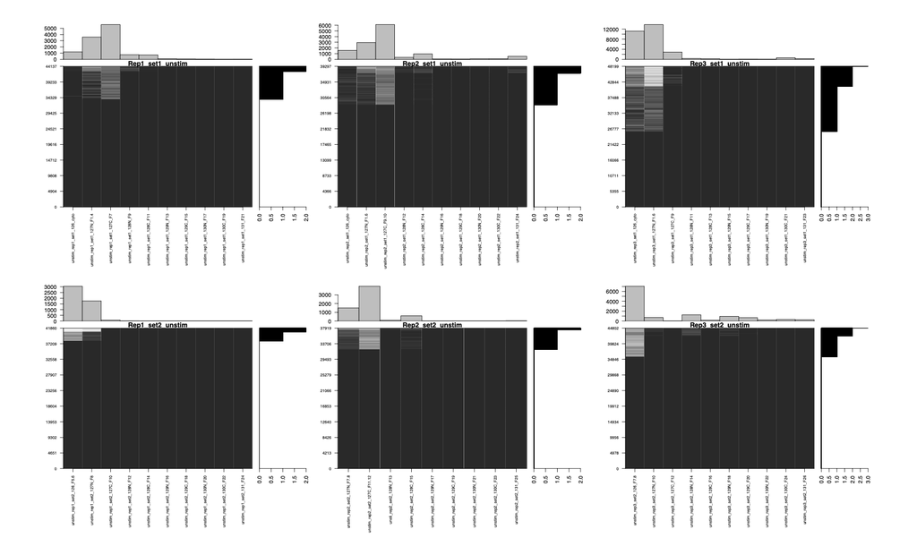

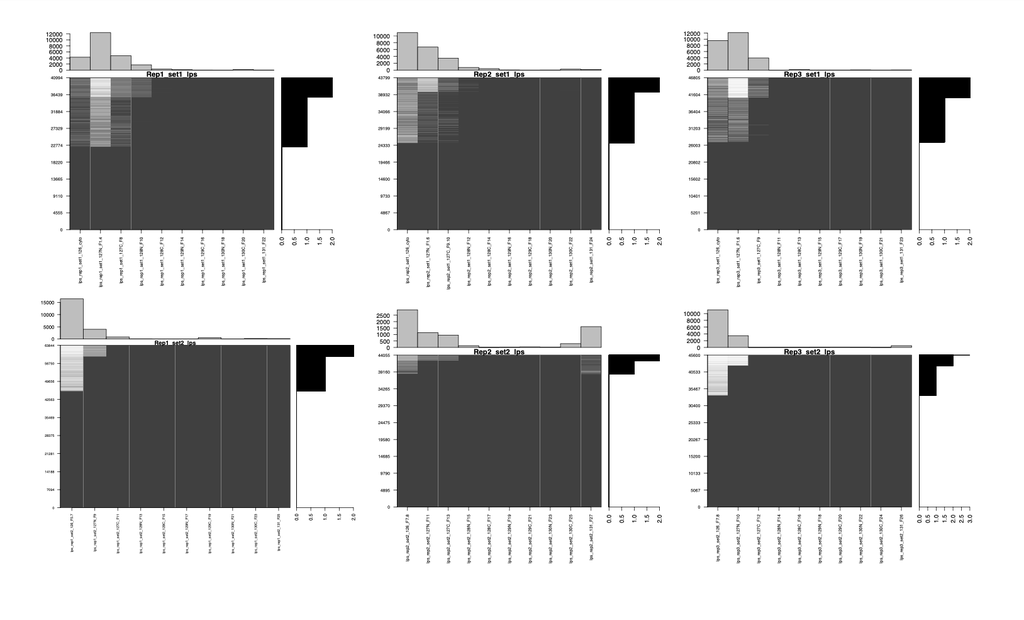

```r
for (i in seq(psms)) {
  par(las = 2, oma = c(10, 1, 1, 1))
  naplot(psms[[i]], col = "black", las = 2, reorderColumns = FALSE,
         main = names(psms)[i], cex.axis = 2)
}
```

*Figure 2. Heatmaps showing missing value distributions per set and replciate*

```r
psms.imputed <- lapply(psms, function(z) impute(z, method = "MinDet"))
```

PSMs were quality controlled post-imputation and then combined to protein level by calculating the median of all PSM intensities corresponding to the leading Uniprot Accession number for each protein group.

### Normalise

Following the standard [pRoloc workflow](https://f1000research.com/articles/5-2926) [6] PSMs are scaled into the same intensity interval by dividing each intensity by the `sum` of the intensities for that quantitative feature. This transformation of the data assures cancellation of the effect of the absolute intensities of the quantitative features along the rows, and focuses subsequent analyses on the relative profiles along the sub-cellular channels. This is important for spatial proteomic experiments are proteins that co-localise in a cell are known to exhibit similar quantitative profiles across the gradient fractions employed [8].

```r
psms.imputed.norm <- lapply(psms.imputed, function(z) normalise(z,  "sum"))
```

### Aggregate to protein level

We use **all** available PSMs for quantification and aggregate PSMs to proteins using the `combineFeatures` function in `MSnbase` by calculating the median of all PSM intensities corresponding to the leading Uniprot Accession number for each protein group.

```r
prots <- lapply(psms.imputed.norm, function(z)
  combineFeatures(z, method = "median",
                  groupBy = fData(z)[, "Master.Protein.Accessions"]))

## become combining all protein sets we tidy up the feature labels of the dataset
ll <- paste0(rep(c("unst", "lps"), 1, each = 6), ".r",
             rep(1:3, 1, each = 2), ".s", 1:2)
for (i in seq(prots)) {
  prots@x[[i]] <- updateFvarLabels(prots[[i]], label = ll[i], sep = "_")
}

## combine TMT sets and examine each replicate for each condition
unst_r1 <- filterNA(MSnbase::combine(prots[[1]], prots[[2]]))
unst_r2 <- filterNA(MSnbase::combine(prots[[3]], prots[[4]]))
unst_r3 <- filterNA(MSnbase::combine(prots[[5]], prots[[6]]))
lps_r1 <- filterNA(MSnbase::combine(prots[[7]], prots[[8]]))
lps_r2 <- filterNA(MSnbase::combine(prots[[9]], prots[[10]]))
lps_r3 <- filterNA(MSnbase::combine(prots[[11]], prots[[12]]))


tot_prots <- data.frame("Unstimulated" = c(`Replicate 1` = nrow(unst_r1),
                                           `Replicate 2` = nrow(unst_r2),
                                           `Replicate 3`= nrow(unst_r3)),
                        "Stimulated 12h-LPS" = c(`Replicate 1` = nrow(lps_r1),
                                                 `Replicate 2` = nrow(lps_r2),
                                                 `Replicate 3` = nrow(lps_r3)))
```

```r
library("knitr")
library("kableExtra")
kable(tot_prots, caption = "Number of quantified proteins per replicate per condition") %>%
  kable_minimal()
```

Number of quantified proteins per replicate per condition

|  | Unstimulated | Stimulated.12h.LPS |
| --- | --- | --- |
| Replicate 1 | 5107 | 4879 |
| Replicate 2 | 4838 | 4866 |
| Replicate 3 | 5733 | 5848 |

## Protein level data processing

```r
## Load R packages required for genetrating Venn diagrams
library("VennDiagram")
library("scales")
library("ggplot2")

venn.diagram(
  x = list(featureNames(unst_r1), featureNames(unst_r2), featureNames(unst_r3)),
  category.names = c("Replicate 1" , "Replicate 2 " , "Replicate 3"),
  filename = "venn_unst_replicates.png",
  main = "Unstimulated hyperLOPIT",
  col=c("#440154ff", '#21908dff', '#fde725ff'),
  fill = c(alpha("#440154ff",0.3), alpha('#21908dff',0.3), alpha('#fde725ff',0.3)),
  fontfamily = "sans",
  cat.fontfamily = "sans",
  main.fontfamily = "sans",
  cat.col = c("#440154ff", '#21908dff', '#fde725ff'),
  output = FALSE
)

venn.diagram(
  x = list(featureNames(lps_r1), featureNames(lps_r2), featureNames(lps_r3)),
  category.names = c("Replicate 1" , "Replicate 2 " , "Replicate 3"),
  filename = "venn_lps_replicates.png",
  main = "LPS stimulated hyperLOPIT 12h-LPS",
  col=c("#440154ff", '#21908dff', '#fde725ff'),
  fill = c(alpha("#440154ff",0.3), alpha('#21908dff',0.3), alpha('#fde725ff',0.3)),
  fontfamily = "sans",
  cat.fontfamily = "sans",
  main.fontfamily = "sans",
  cat.col = c("#440154ff", '#21908dff', '#fde725ff')
)
```

## Dataset concatenation

We use the `combine` function in `MSnbase` to perform data fusion (concatenation) within each condition to maximise subcellular resolution and thus the reliability in protein classification [as per the pRoloc pipeline [5, 6] and in [7]]. Trotter et al. [7] have shown a significant improvement in classifier accuracy when combining replicated experiments in spatial proteomics. Specifically, we concatenate all gradient fractions across replicated experiments to give better discrimination between subcellular niches (as shown in [7]) which gives users the opportunity to resolve niches that may not have been discovered when examining replicates alone.

We note (as explained in [5, 6]) that direct comparisons of individual TMT channels in replicated experiments do not provide an adequate, goal-driven assessment of different experiments due to the nature of the gradient fraction collection, where quantitative channels do not correspond to identical selected fractions along the gradient.

Concatenate replicates for each condition,

```r
## combine replicates for each condition
unst_full <- filterNA(MSnbase::combine(unst_r1, unst_r2))
unst_full <- filterNA(MSnbase::combine(unst_full, unst_r3))

lps_full <- filterNA(MSnbase::combine(lps_r1, lps_r2))
lps_full <- filterNA(MSnbase::combine(lps_full, lps_r3))
```

```r
venn.diagram(
  x = list(featureNames(unst_full), featureNames(lps_full)),
  category.names = c("Unstimulated" , "LPS-stimulated"),
  filename = "venn_hyperLOPIT.png",
  main = "Subset of common proteins between hyperLOPIT conditions",
  col=c("#440154ff", '#21908dff'),
  fill = c(alpha("#440154ff",0.3), alpha('#21908dff',0.3)),
  fontfamily = "sans",
  cat.fontfamily = "sans",
  main.fontfamily = "sans",
  cat.col = c("#440154ff", '#21908dff'),
  margin = 0.05,
  cat.pos = c(-140, 140),
  cat.dist = c(0.05, 0.05)
)
```

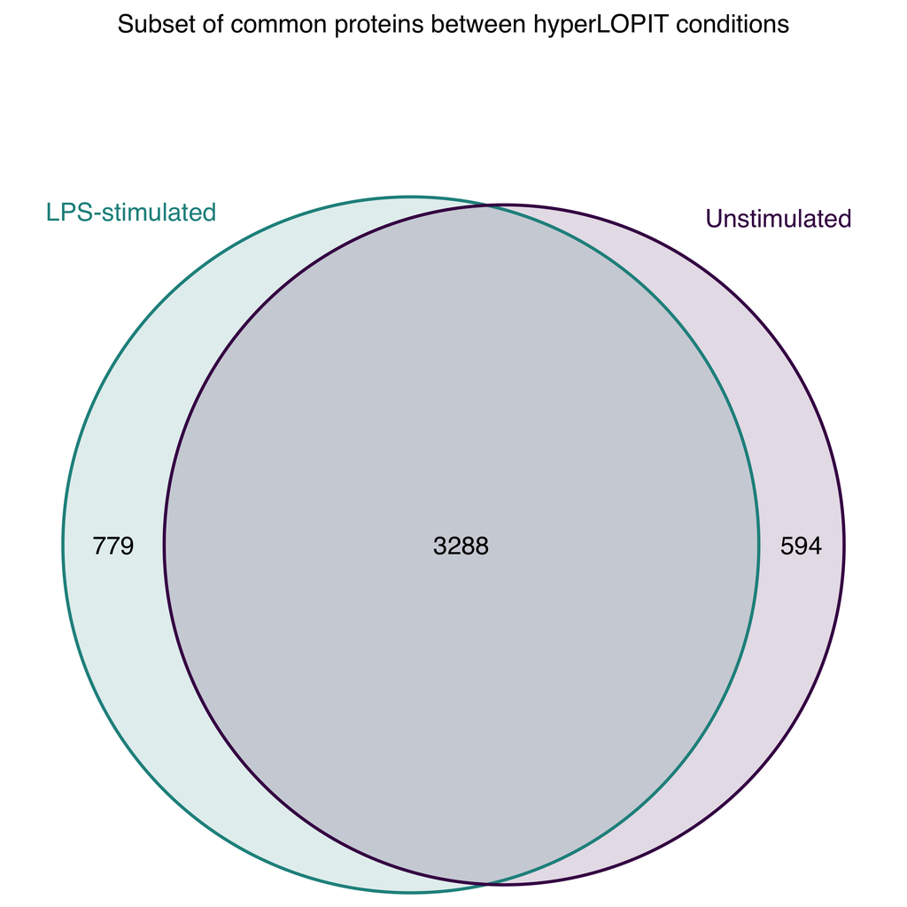

*Figure 4. Overlap of protein groups identified in both conditions*

We find 3288 proteins common all 12 experiments. In the next code chunk we subset our data to keep only proteins common between all experiments.

### Final hyperLOPIT datasets for downstream analysis

Subset for common proteins in all replicates and all conditions,

```r
## keep only those in common between conditions
cmn <- intersect(featureNames(unst_full), featureNames(lps_full))
lps <- lps_full[cmn, ]
unst <- unst_full[cmn, ]
```

### Adding marker proteins

A list of 783 annotated, unambiguous resident organelle marker proteins from 11 subcellular niches: mitochondria, ER, Golgi apparatus, lysosome, peroxisome, PM, nucleus, nucleolus, chromatin, ribosome and cytosol, were curated from [The Uniprot database](https://www.uniprot.org), [Gene Ontology](https://www.ebi.ac.uk/QuickGO/) and from careful mining of the literature. Only proteins known to localise to a single location were included as markers.

We use the `addMarkers` function in `pRoloc` to annotate our two datasets from this list of markers (found in the `csv` directory of this repository). The marker list can also be extracted from `pRolocdata` by using the `getMarkers` function with any of the THP datasets.

Adding markers,

```r
lps <- addMarkers(lps, markers = "csv/markers_2019.28.01.csv")
```

```
## Markers in data: 783 out of 3288
```

```
## organelleMarkers
##      40S/60S Ribosome             Chromatin               Cytosol
##                    75                    73                    52
## Endoplasmic Reticulum       Golgi Apparatus              Lysosome
##                    69                    39                    49
##          Mitochondria             Nucleolus               Nucleus
##                   197                    38                    91
##            Peroxisome       Plasma Membrane               unknown
##                    29                    71                  2505
```

```r
unst <- addMarkers(unst, markers = "csv/markers_2019.28.01.csv")
```

```
## Markers in data: 783 out of 3288
```

```
## organelleMarkers
##      40S/60S Ribosome             Chromatin               Cytosol
##                    75                    73                    52
## Endoplasmic Reticulum       Golgi Apparatus              Lysosome
##                    69                    39                    49
##          Mitochondria             Nucleolus               Nucleus
##                   197                    38                    91
##            Peroxisome       Plasma Membrane               unknown
##                    29                    71                  2505
```

### Visualising the data

In the below code chunk we plot the data and highlight the subcellular markers on each dataset (Figure 4 of [1]). Each point represents one protein. Markers are highlighted by different colours as denoted by the key and proteins for the subcellular location is unknown or undefined are grey.

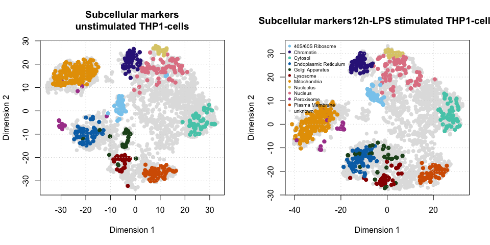

```r
## set organelle colours
mycol <- c("#88CCEE", "#332288", "#53CAB7", "#0170b4", "#204f20", "#990000",
           "#E69F00", "#DDCC77", "#E18493", "#AA4499", "#D55E00",  "#7E7E30")
setStockcol(mycol)
setUnknownpch(16)


## Generate the t-SNE coords (Figure 4 of [1])
set.seed(399)
tsne_unst <- plot2D(unst, method = "t-SNE", plot = FALSE)
set.seed(399)
tsne_lps <- plot2D(lps, method = "t-SNE", plot = FALSE)


## plot the data as t-SNE maps
par(mfrow = c(1, 2))
plot2D(tsne_unst, method = "none", methargs = list(unst),
       fcol = "markers", main = "Subcellular markers\nunstimulated THP1-cells")
plot2D(tsne_lps, method = "none", methargs = list(lps),
       fcol = "markers", main = "Subcellular markers12h-LPS stimulated THP1-cells")
addLegend(lps, where = "topleft", cex = .6)
```

*Figure 5. t-SNE plots of the (concatenated) LOPIT datasets for each condition (Figure 4 of [1])*